# warmup1

Carolus Chan

February 4, 2019

[figure not shown]

A famous quote from Neeku Vozo:

> *“I once had a pet named Lucky that reminded me of home.and then it died.and then I ate it! And it was supremely delicious!”*

| Physical Descrpition |  |
| --- | --- |
| Species | Nikto |
| Gender | Male |
| Eye color | Black |
| Skin color | Green |

# **Baked Buffalo Wings**

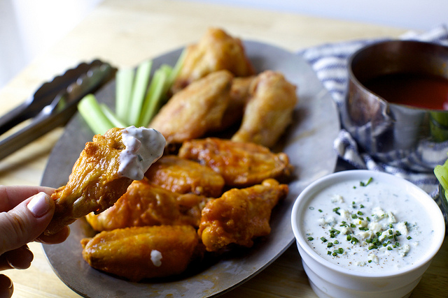

## Ingredients

- 1 to 4 pounds chicken wings that have been cut into flats and drumettes
- 1 1/2 teaspoons to 2 tablespoons baking powder (using 1 1/2 teaspoons per pound)
- 1 to 4 teaspoons kosher salt (using 1 teaspoon per pound; use less salt if you’re not using Diamond brand)
- 2 tablespoons hot sauce (Frank’s RedHot is traditional) per pound of wings
- 1 1/2 to 2 tablespoons unsalted butter per pound of wings

## Required kitchen items

- large baking sheet
- oven safe cooling rack
- tongs or spatula to flip wings
- large bowl

## Instructions

1. Pat wings dry with a paper towel, and then, in a large bowl, toss them with 1 1/2 teaspoons baking powder and 1 teaspoon kosher salt per pound of wings, until thoroughly coated.
2. Arrange them on the rack with some space between them (the surface will not dry and crisp as well where they touch) and place in your refrigerator uncovered for 8 to 24 hours.
3. When you’re ready to bake them, heat your oven to 450 degrees, with a rack set in the top half of your oven.
4. Bake your wings for 20 minutes, flip them with tongs or a spatula, bake them for another 15 minutes, flip them back over again, and then for 15 final minutes, for a total roasting time of 50 minutes. Wings are done with they are browned and crisp.
5. While the wings roast, make Buffalo wing sauce. In a medium saucepan, for each pound of wings, combine 2 tablespoons of hot sauce and 1 1/2 tablespoons (for a hotter sauce) to 2 tablespoons (for a mild, more buttery sauce) unsalted butter over medium heat until melted, whisking to combine.
6. When wings are done, roll each in prepared Buffalo wing sauce. Serve with fixings of your choice. Eat immediately.

# Definition <sub>[edit]</sub>

The **Euclidean distance** between points **p** and **q** is the length of the line segment connecting them ($\overline{\mathbf{pq}}$).

In Cartesian coordinates, if **p** = (p<sub>1</sub>, p<sub>2</sub>,…, p<sub>n</sub>) and q = (q<sub>1</sub>, q<sub>2</sub>,…, q<sub>n</sub>) are two points in Euclidean *n*-space, then the distance (d) from **p** to **q**, or from **q** to **p** is given by the Pythagorean formula:

$$\begin{equation}
\begin{split}
|| \mathbf{p} || = \sqrt{p_1^2+p_2^2+\cdots+p_n^2} = \sqrt{\mathbf{p} \cdot \mathbf{p}},
\end{split}
\end{equation}$$

where the last expression involves the dot product.